# Modelling Peak Electricity Demand in Great Britain

# Data description and exploratory analysis

## Data visualization and pre-processing

To prepare our data for analysis, we began by dropping unneeded coefficients. This was a list that changed over the course of our improvements on our candidate model, as we made informed changes to our model versions. Below is an initial covariate matrix that we used to get an overview of which columns could provide information on our response variable.

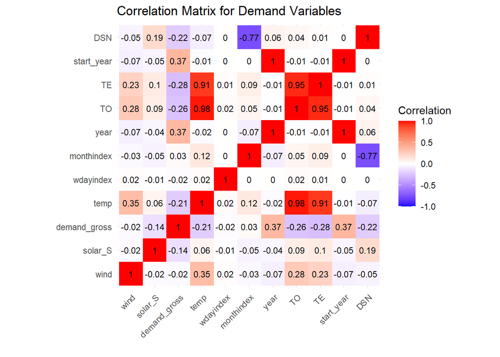

Figure 1: Correletion matrix for all variables in the dataset SCS_demand_modelling.csv.

Firstly what we see from this plot is that there are many variables that have exceptionally high correlation. Inspecting which pairs these are, we observe that many of these are defined as transformations of one another, which explains their exceptionally high correlation. A major example of this is the “TO” and “TE” relationship.

We can see that the “year” variable has a moderate positive correlation to “demand_gross”, and both “TO” and “TE” have a moderate negative correlation. These are some examples of how we might choose candidate models in order to improve upon the baseline model. The following plots; Figure (2), Figure (3), Figure (4) and Figure (5) provide insight on the precise nature of the relationship between gross demand and year, month, day and temperature respectively. These plots were instrumental in informing our choice of model.

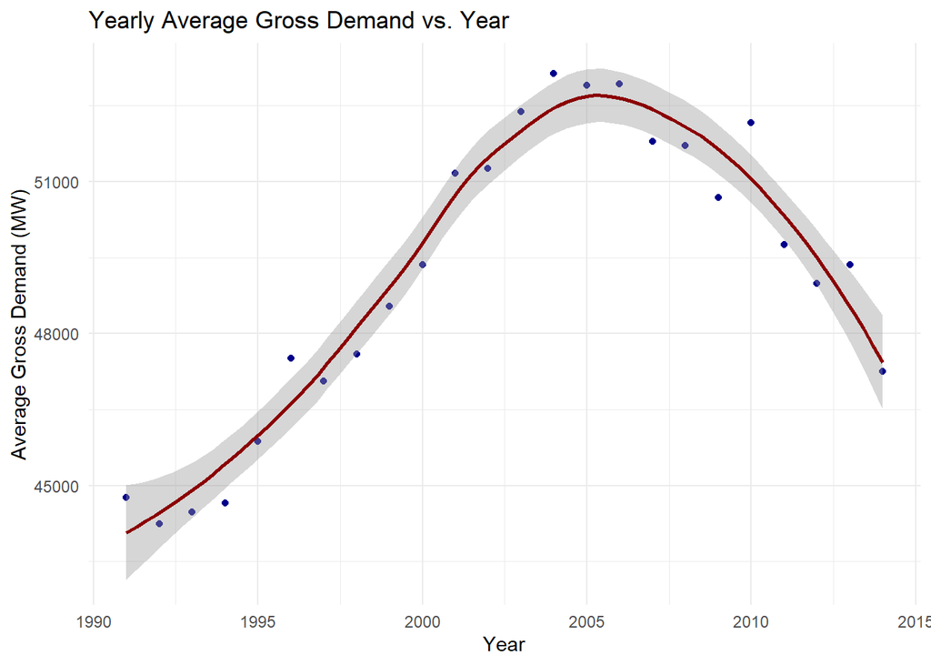

Figre 2: Plot of average yearly gross demand against year, highlighting their non-linear relationship.

From the plot presented above, we observe a strong relationship between the year and the average yearly gross demand. We plotted average gross demand as solely a function of year, thus we initially conjectured some cyclical or polynomial relationship. However, the plot we observe here is sufficient for us to confidently include year as a covariate in our candidate models going forwards.

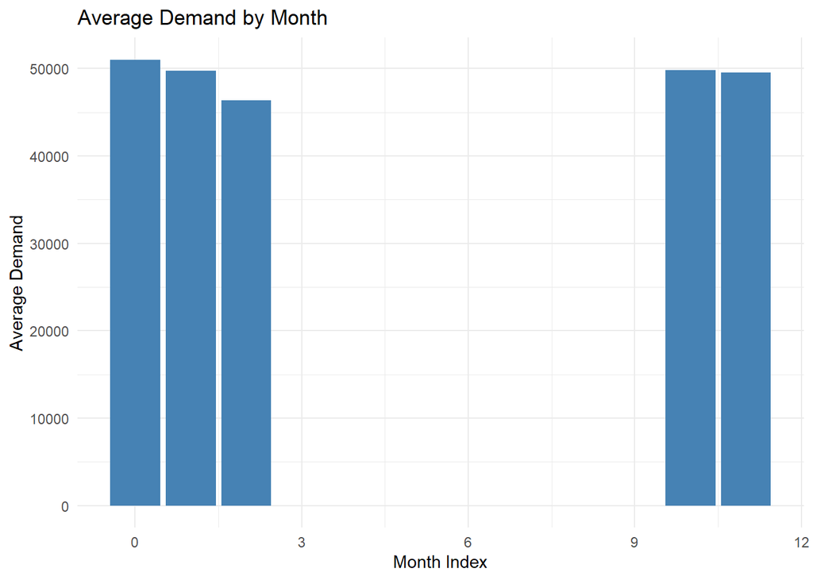

Figure 3: Bar plot of average monthly gross demand against month, for the months of January(0), February(1), March(2), November(10) and December(11). This highlights the significant difference between March and the other months.

As the number of data points on the month scale was sufficiently low, in the previous plot we chose to use a bar plot instead of treating the time scale as continuous.

The most visible result here is the difference between the month of March and the other months, with the month of March exhibiting lower average monthly gross demand than the other months. Qualitatively we can expect this, as March would be expected to be different in terms of weather to the other months for which we have data. It is reasonable to expect this to translate into a lower gross demand during this time.

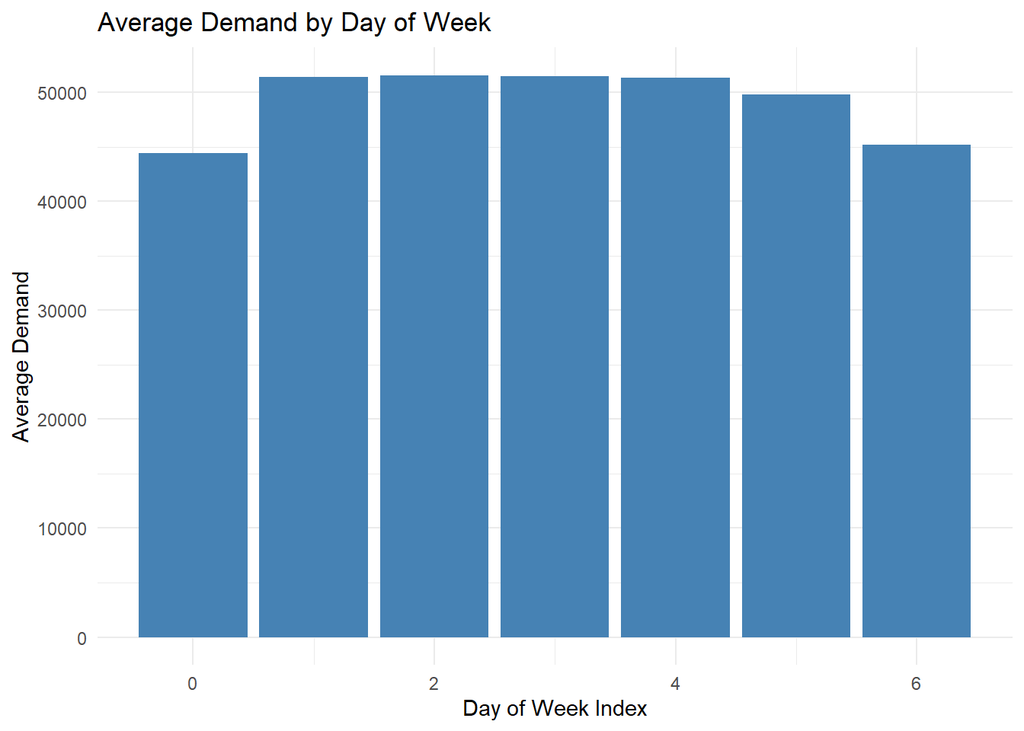

Figure 4: Bar plot of average gross demand against day, for the days of the week, that is Sunday(0), Monday(1), Tuesday(2), Wednesday(3), Thursday(4), Friday(5) and Saturday(6). This highlights the difference between weekend days(Sunday and Saturday) and the other days.

Similarly to the month case, the above plot shows that there is a noticeable difference between the average gross demand of weekend days and weekdays. This is expected, as during weekends energy demand towards office lighting and heating, as well as commuting is lower, as a significant portion of the population does not work.

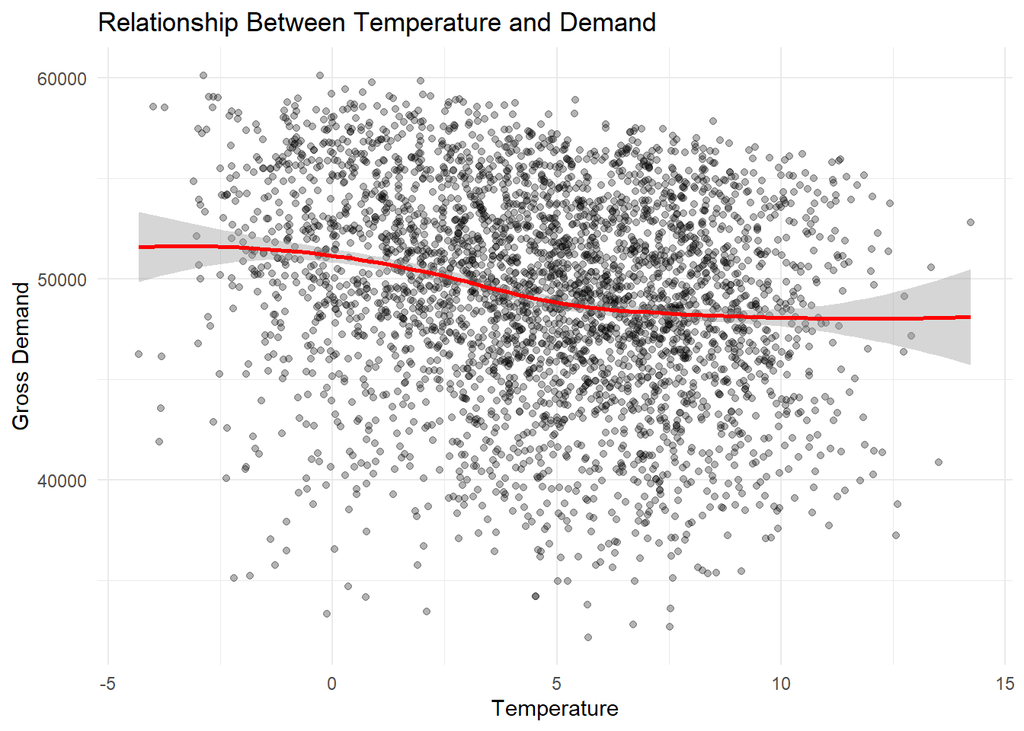

A reasonable assumption would be to expect energy demand to decrease with temperature, as the energy required to heat homes is reduced. Indeed the plot above supports this intuition, showing a negative correlation, although relatively weak between the two variables.